# Devoir 2 : Raphaël Poix & Jeremy Uzan

# Modèle de translation : loi de Student

L’objectif de ce devoir est d’évaluer la meilleur façon d’estimer le paramètre de translation $\theta$ d’une loi de Student translatée. Nous savons déjà que trois estimateurs tendent en probabilité vers $\theta$ :

1. la moyenne empirique, estimateur obtenu par la méthode des moments.
2. la médiane empirique, car la loi est symétrique par rapport à $\theta$.
3. la moyenne empirique tronquée qui correspond à la moyenne empirique après suppression des observations les plus extrêmes de l’échantillon.

Nous allons utiliser la Methode Monte-Carlo vue au TP n°4.

On considère la variable aléatoire $X$ définie comme :
$$X=Z+\theta$$

où $\theta \in R$ est une constante et $Z$ une variable aléatoire de loi de Student $t(q)$ à q degrés de liberté. Nous supposons que q est connu et le paramètre $\theta$ est inconnu. Le but est l’estimation de $\theta$ à partir de n copies i.i.d. $(X_1,…,X_n)$ de $X$.

Rappelons qu’un critère pour évaluer la qualité d’un estimateur $\widehat{\theta}$ de $\theta$ est son risque quadratique définit par : $R(\theta,\widehat{\theta})=\mathbb{E}[ ( \widehat{\theta} - \theta)^2]$

Dans notre modèle le risque quadratique de la moyenne empirique ($\widehat{\theta}=\overline{X_n}$) n’est pas explicite, car la loi de la variable aléatoire $T=(\widehat{\theta} - \theta)^2$ est difficile à déterminer. Nous choisissons alors d’analyser le comportement de $\widehat{\theta}$ sur des données simulées.

Plus précisément, l’idée consiste à approcher l’espérance dans la définition du risque quadratique par une moyenne empirique en simulant un grand nombre de réalisations $T(k)$ de la variable $T = (\widehat{\theta} - \theta)^2$.

L’unique aléa dans $T$ vient de l’échantillon $(X_1,…,X_n)$, car l’estimateur $\widehat{\theta}$ est une fonction mesurable sur l’espace des observations $(X_1,…,X_n)$. On obtient une réalisation $T(k)$ de $T$ :

1. en générant un échantillon $(x_1^k,...,x_n^k)$ et
2. en évaluant cet échantillon simulé (c’est-à-dire en sortir l’estimateur et appliquer la formule pour $T$).

On répète cette démarche K fois pour créer un échantillon $(T_1,…,T_K)$. Ensuite, il ne reste à calculer la moyenne empirique $\overline{T_K}$ des $(T_1,…,T_K)$ qui est une approximation du risque quadratique.

C’est le principe des simulations dites de Monte Carlo. Ce procédé est justifié par la loi des grands nombres, $\overline{T_k}$ tend en probablité vers $R(\widehat{\theta},\theta)$

Ainsi, plus le nombre K de réalisations Tk est grand, mieux est l’approximation du risque quadratique $R(\widehat{\theta},\theta)$ par $\overline{T_K}$. On appele $\overline{T_K}$ le risque quadratique empirique

```r
  k=100        #le nombre d'échantillons générés
  n=200        #taille de chaque échantillon
  q=10          #degrés de liberté de la loi de Student générée
  theta=2      #paramètre de translation de la loi
  gamma=0.04   #proportion à retirer dans la moyenne tronquée
```

On va tout d’abord tracer les Box-plot des estimateurs, pour se faire une idée sur leur comportement.

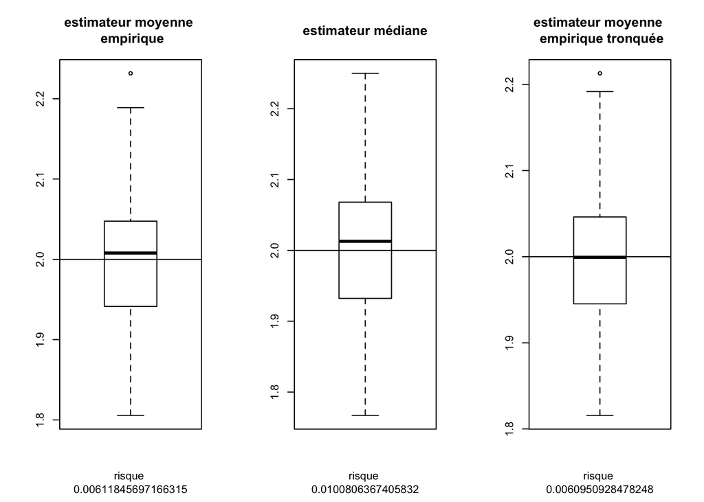